# Analysis of Ford GoBike System Data

## Introduction

This data set includes information about individual rides made in a bike-sharing system covering the greater San Francisco Bay area. https://video.udacity-data.com/topher/2020/October/5f91cf38_201902-fordgobike-tripdata/201902-fordgobike-tripdata.csv

The Data consists of 13 variables and includes:

1. Trip Duration (seconds)
2. Start Time and Date
3. End Time and Date
4. Start Station ID
5. Start Station Name
6. Start Station Latitude
7. Start Station Longitude
8. End Station ID
9. End Station Name
10. End Station Latitude
11. End Station Longitude
12. Bike ID
13. User Type (Subscriber or Customer – “Subscriber” = Member or “Customer” = Casual)

## Preliminary Wrangling

```python
# import all packages and set plots to be embedded inline
import numpy as np
import pandas as pd
import matplotlib.pyplot as plt
import seaborn as sb
import datetime

%matplotlib inline
```

```python
#Loading data into dataset
ford_bike = pd.read_csv('201902-fordgobike-tripdata.csv')
```

### Accessing the Dataset

```python
#checking the data samples
ford_bike.head(10)
```

|  | duration_sec | start_time | end_time | start_station_id | start_station_name | start_station_latitude | start_station_longitude | end_station_id | end_station_name | end_station_latitude | end_station_longitude | bike_id | user_type | member_birth_year | member_gender | bike_share_for_all_trip |
| --- | --- | --- | --- | --- | --- | --- | --- | --- | --- | --- | --- | --- | --- | --- | --- | --- |
| 0 | 52185 | 2019-02-28 17:32:10.1450 | 2019-03-01 08:01:55.9750 | 21.0 | Montgomery St BART Station (Market St at 2nd St) | 37.789625 | -122.400811 | 13.0 | Commercial St at Montgomery St | 37.794231 | -122.402923 | 4902 | Customer | 1984.0 | Male | No |
| 1 | 42521 | 2019-02-28 18:53:21.7890 | 2019-03-01 06:42:03.0560 | 23.0 | The Embarcadero at Steuart St | 37.791464 | -122.391034 | 81.0 | Berry St at 4th St | 37.775880 | -122.393170 | 2535 | Customer | NaN | NaN | No |
| 2 | 61854 | 2019-02-28 12:13:13.2180 | 2019-03-01 05:24:08.1460 | 86.0 | Market St at Dolores St | 37.769305 | -122.426826 | 3.0 | Powell St BART Station (Market St at 4th St) | 37.786375 | -122.404904 | 5905 | Customer | 1972.0 | Male | No |
| 3 | 36490 | 2019-02-28 17:54:26.0100 | 2019-03-01 04:02:36.8420 | 375.0 | Grove St at Masonic Ave | 37.774836 | -122.446546 | 70.0 | Central Ave at Fell St | 37.773311 | -122.444293 | 6638 | Subscriber | 1989.0 | Other | No |
| 4 | 1585 | 2019-02-28 23:54:18.5490 | 2019-03-01 00:20:44.0740 | 7.0 | Frank H Ogawa Plaza | 37.804562 | -122.271738 | 222.0 | 10th Ave at E 15th St | 37.792714 | -122.248780 | 4898 | Subscriber | 1974.0 | Male | Yes |
| 5 | 1793 | 2019-02-28 23:49:58.6320 | 2019-03-01 00:19:51.7600 | 93.0 | 4th St at Mission Bay Blvd S | 37.770407 | -122.391198 | 323.0 | Broadway at Kearny | 37.798014 | -122.405950 | 5200 | Subscriber | 1959.0 | Male | No |
| 6 | 1147 | 2019-02-28 23:55:35.1040 | 2019-03-01 00:14:42.5880 | 300.0 | Palm St at Willow St | 37.317298 | -121.884995 | 312.0 | San Jose Diridon Station | 37.329732 | -121.901782 | 3803 | Subscriber | 1983.0 | Female | No |
| 7 | 1615 | 2019-02-28 23:41:06.7660 | 2019-03-01 00:08:02.7560 | 10.0 | Washington St at Kearny St | 37.795393 | -122.404770 | 127.0 | Valencia St at 21st St | 37.756708 | -122.421025 | 6329 | Subscriber | 1989.0 | Male | No |
| 8 | 1570 | 2019-02-28 23:41:48.7900 | 2019-03-01 00:07:59.7150 | 10.0 | Washington St at Kearny St | 37.795393 | -122.404770 | 127.0 | Valencia St at 21st St | 37.756708 | -122.421025 | 6548 | Subscriber | 1988.0 | Other | No |
| 9 | 1049 | 2019-02-28 23:49:47.6990 | 2019-03-01 00:07:17.0250 | 19.0 | Post St at Kearny St | 37.788975 | -122.403452 | 121.0 | Mission Playground | 37.759210 | -122.421339 | 6488 | Subscriber | 1992.0 | Male | No |

```python
#Checking the datatype of each columns in the dataset
ford_bike.info()
```

```
<class 'pandas.core.frame.DataFrame'>
RangeIndex: 183412 entries, 0 to 183411
Data columns (total 16 columns):
duration_sec               183412 non-null int64
start_time                 183412 non-null object
end_time                   183412 non-null object
start_station_id           183215 non-null float64
start_station_name         183215 non-null object
start_station_latitude     183412 non-null float64
start_station_longitude    183412 non-null float64
end_station_id             183215 non-null float64
end_station_name           183215 non-null object
end_station_latitude       183412 non-null float64
end_station_longitude      183412 non-null float64
bike_id                    183412 non-null int64
user_type                  183412 non-null object
member_birth_year          175147 non-null float64
member_gender              175147 non-null object
bike_share_for_all_trip    183412 non-null object
dtypes: float64(7), int64(2), object(7)
memory usage: 22.4+ MB
```

```python
#Checking random samples in the data
ford_bike.sample(15)
```

|  | duration_sec | start_time | end_time | start_station_id | start_station_name | start_station_latitude | start_station_longitude | end_station_id | end_station_name | end_station_latitude | end_station_longitude | bike_id | user_type | member_birth_year | member_gender | bike_share_for_all_trip |
| --- | --- | --- | --- | --- | --- | --- | --- | --- | --- | --- | --- | --- | --- | --- | --- | --- |
| 114259 | 200 | 2019-02-12 09:51:48.5360 | 2019-02-12 09:55:09.1790 | 121.0 | Mission Playground | 37.759210 | -122.421339 | 223.0 | 16th St Mission BART Station 2 | 37.764765 | -122.420091 | 485 | Subscriber | 1981.0 | Female | Yes |
| 64092 | 582 | 2019-02-20 12:59:04.2760 | 2019-02-20 13:08:46.8890 | 22.0 | Howard St at Beale St | 37.789756 | -122.394643 | 77.0 | 11th St at Natoma St | 37.773507 | -122.416040 | 6260 | Subscriber | NaN | NaN | No |
| 39166 | 305 | 2019-02-23 10:11:26.9100 | 2019-02-23 10:16:31.9870 | 236.0 | Market St at 8th St | 37.803686 | -122.282497 | 160.0 | West Oakland BART Station | 37.805318 | -122.294837 | 3324 | Subscriber | 1994.0 | Male | No |
| 30476 | 73 | 2019-02-24 19:52:39.5510 | 2019-02-24 19:53:52.6610 | 91.0 | Berry St at King St | 37.771762 | -122.398438 | 91.0 | Berry St at King St | 37.771762 | -122.398438 | 4733 | Subscriber | 1995.0 | Female | No |
| 179659 | 926 | 2019-02-01 13:01:30.1770 | 2019-02-01 13:16:56.9120 | 337.0 | Webster St at 19th St | 37.806970 | -122.266588 | 162.0 | Franklin St at 9th St | 37.800516 | -122.272080 | 5311 | Subscriber | 1966.0 | Male | No |
| 25096 | 973 | 2019-02-25 17:18:52.1200 | 2019-02-25 17:35:06.0390 | 148.0 | Horton St at 40th St | 37.829705 | -122.287610 | 372.0 | Madison St at 17th St | 37.804037 | -122.262409 | 6407 | Subscriber | 1994.0 | Female | No |
| 18006 | 732 | 2019-02-26 19:41:26.6630 | 2019-02-26 19:53:38.8610 | 134.0 | Valencia St at 24th St | 37.752428 | -122.420628 | 42.0 | San Francisco City Hall (Polk St at Grove St) | 37.778650 | -122.418230 | 5547 | Subscriber | 1973.0 | Male | Yes |
| 175804 | 292 | 2019-02-02 13:25:10.9520 | 2019-02-02 13:30:02.9790 | 114.0 | Rhode Island St at 17th St | 37.764478 | -122.402570 | 116.0 | Mississippi St at 17th St | 37.764802 | -122.394771 | 4653 | Subscriber | 1992.0 | Male | No |
| 156322 | 324 | 2019-02-06 08:05:55.6960 | 2019-02-06 08:11:19.7810 | 195.0 | Bay Pl at Vernon St | 37.812314 | -122.260779 | 337.0 | Webster St at 19th St | 37.806970 | -122.266588 | 3501 | Subscriber | 1968.0 | Female | No |
| 167564 | 515 | 2019-02-04 17:06:19.8610 | 2019-02-04 17:14:55.2740 | 30.0 | San Francisco Caltrain (Townsend St at 4th St) | 37.776598 | -122.395282 | 22.0 | Howard St at Beale St | 37.789756 | -122.394643 | 4801 | Subscriber | 1985.0 | Male | No |
| 57661 | 846 | 2019-02-21 07:58:33.3320 | 2019-02-21 08:12:39.8960 | 160.0 | West Oakland BART Station | 37.805318 | -122.294837 | 153.0 | 59th St at Horton St | 37.840945 | -122.291360 | 6245 | Customer | 1984.0 | Female | No |
| 25645 | 358 | 2019-02-25 16:34:27.2220 | 2019-02-25 16:40:26.0600 | 80.0 | Townsend St at 5th St | 37.775235 | -122.397437 | 5.0 | Powell St BART Station (Market St at 5th St) | 37.783899 | -122.408445 | 6188 | Subscriber | 1985.0 | Male | No |
| 5118 | 1133 | 2019-02-28 13:48:39.4110 | 2019-02-28 14:07:32.5310 | 296.0 | 5th St at Virginia St | 37.325998 | -121.877120 | 286.0 | San Carlos St at 11th St | 37.336466 | -121.876613 | 6022 | Subscriber | 1996.0 | Female | Yes |
| 130480 | 550 | 2019-02-09 17:13:29.6710 | 2019-02-09 17:22:40.2690 | 3.0 | Powell St BART Station (Market St at 4th St) | 37.786375 | -122.404904 | 11.0 | Davis St at Jackson St | 37.797280 | -122.398436 | 1838 | Subscriber | 1993.0 | Male | No |
| 156583 | 345 | 2019-02-06 07:48:03.0330 | 2019-02-06 07:53:48.0680 | 178.0 | Broadway at 30th St | 37.819381 | -122.261928 | 182.0 | 19th Street BART Station | 37.809013 | -122.268247 | 3504 | Subscriber | 1993.0 | Female | No |

```python
#checking for null values in the data set
ford_bike.isnull().sum()
```

```
duration_sec                  0
start_time                    0
end_time                      0
start_station_id            197
start_station_name          197
start_station_latitude        0
start_station_longitude       0
end_station_id              197
end_station_name            197
end_station_latitude          0
end_station_longitude         0
bike_id                       0
user_type                     0
member_birth_year          8265
member_gender              8265
bike_share_for_all_trip       0
dtype: int64
```

```python
#checking for duplicate values in the data set
ford_bike.duplicated().sum()
```

```
0
```

```python
# Checking the unique strings in member_gender
ford_bike['member_gender'].unique()
```

```
array(['Male', nan, 'Other', 'Female'], dtype=object)
```

```python
# Checking value counts for each gender
ford_bike['member_gender'].value_counts()
```

```
Male      130651
Female     40844
Other       3652
Name: member_gender, dtype: int64
```

### Assessment Issues

#### Quality

1. start_time and end_time columns in object dtype instead of datetime dtype
2. member_birth_year in float instead of int dtype
3. bike_id column in int dtype instead of object dtype
4. user_type in object dtype instead of categorical dtype
5. start_station_latitude, start_station_longitude, end_station_latitude, and end_station_longitude columns in float64 dtype instead of object dtype
6. 8265 Missing Values in both member_birth_year and member_gender columns
7. 197 Missing entries in start_station id, start_station_name columns, end_station_id and end_station_name columns
8. 3652 Other gender present in member_gender column

### Data Cleaning

```python
#Creating a new copy for the data cleaning operation
ford_bike_1 = ford_bike.copy()
#Testing Code
ford_bike_1.head()
```

|  | duration_sec | start_time | end_time | start_station_id | start_station_name | start_station_latitude | start_station_longitude | end_station_id | end_station_name | end_station_latitude | end_station_longitude | bike_id | user_type | member_birth_year | member_gender | bike_share_for_all_trip |
| --- | --- | --- | --- | --- | --- | --- | --- | --- | --- | --- | --- | --- | --- | --- | --- | --- |
| 0 | 52185 | 2019-02-28 17:32:10.1450 | 2019-03-01 08:01:55.9750 | 21.0 | Montgomery St BART Station (Market St at 2nd St) | 37.789625 | -122.400811 | 13.0 | Commercial St at Montgomery St | 37.794231 | -122.402923 | 4902 | Customer | 1984.0 | Male | No |
| 1 | 42521 | 2019-02-28 18:53:21.7890 | 2019-03-01 06:42:03.0560 | 23.0 | The Embarcadero at Steuart St | 37.791464 | -122.391034 | 81.0 | Berry St at 4th St | 37.775880 | -122.393170 | 2535 | Customer | NaN | NaN | No |
| 2 | 61854 | 2019-02-28 12:13:13.2180 | 2019-03-01 05:24:08.1460 | 86.0 | Market St at Dolores St | 37.769305 | -122.426826 | 3.0 | Powell St BART Station (Market St at 4th St) | 37.786375 | -122.404904 | 5905 | Customer | 1972.0 | Male | No |
| 3 | 36490 | 2019-02-28 17:54:26.0100 | 2019-03-01 04:02:36.8420 | 375.0 | Grove St at Masonic Ave | 37.774836 | -122.446546 | 70.0 | Central Ave at Fell St | 37.773311 | -122.444293 | 6638 | Subscriber | 1989.0 | Other | No |
| 4 | 1585 | 2019-02-28 23:54:18.5490 | 2019-03-01 00:20:44.0740 | 7.0 | Frank H Ogawa Plaza | 37.804562 | -122.271738 | 222.0 | 10th Ave at E 15th St | 37.792714 | -122.248780 | 4898 | Subscriber | 1974.0 | Male | Yes |

```python
#Converting columns with quality issues to the appropriate Datatype
dtype= {'start_time': 'datetime64',
        'end_time': 'datetime64',

        'bike_id': 'object',
        'user_type': 'category',

        'start_station_id': 'object',
        'end_station_id': 'object',

        'start_station_latitude': 'object',
        'start_station_longitude':  'object',
        'end_station_latitude':  'object',
        'end_station_longitude':  'object',}

ford_bike_1 = ford_bike_1.astype(dtype)
```

```python
#Testing to effect changes
ford_bike_1.info()
```

```
<class 'pandas.core.frame.DataFrame'>
RangeIndex: 183412 entries, 0 to 183411
Data columns (total 16 columns):
duration_sec               183412 non-null int64
start_time                 183412 non-null datetime64[ns]
end_time                   183412 non-null datetime64[ns]
start_station_id           183215 non-null object
start_station_name         183215 non-null object
start_station_latitude     183412 non-null object
start_station_longitude    183412 non-null object
end_station_id             183215 non-null object
end_station_name           183215 non-null object
end_station_latitude       183412 non-null object
end_station_longitude      183412 non-null object
bike_id                    183412 non-null object
user_type                  183412 non-null category
member_birth_year          175147 non-null float64
member_gender              175147 non-null object
bike_share_for_all_trip    183412 non-null object
dtypes: category(1), datetime64[ns](2), float64(1), int64(1), object(11)
memory usage: 21.2+ MB
```

```python
#Dropping data with missing member_gender entries
ford_bike_1 = ford_bike_1[ford_bike_1.member_gender.notnull()]
#Dropping data with missing start_station_id entries
ford_bike_1 = ford_bike_1[ford_bike_1.start_station_id.notnull()]
```

```python
#Checking if the rows were dropped
ford_bike_1.info()
```

```
<class 'pandas.core.frame.DataFrame'>
Int64Index: 174952 entries, 0 to 183411
Data columns (total 16 columns):
duration_sec               174952 non-null int64
start_time                 174952 non-null datetime64[ns]
end_time                   174952 non-null datetime64[ns]
start_station_id           174952 non-null object
start_station_name         174952 non-null object
start_station_latitude     174952 non-null object
start_station_longitude    174952 non-null object
end_station_id             174952 non-null object
end_station_name           174952 non-null object
end_station_latitude       174952 non-null object
end_station_longitude      174952 non-null object
bike_id                    174952 non-null object
user_type                  174952 non-null category
member_birth_year          174952 non-null float64
member_gender              174952 non-null object
bike_share_for_all_trip    174952 non-null object
dtypes: category(1), datetime64[ns](2), float64(1), int64(1), object(11)
memory usage: 21.5+ MB
```

```python
#Creating a column for Age frpm member birth year
ford_bike_1['Age'] = ford_bike_1['member_birth_year'].apply(lambda x: 2019 - x)
```

```python
#Dropping member_birth_year
ford_bike_1.drop(['member_birth_year'], axis = 1, inplace = True)
```

```python
#Checking the data
ford_bike_1.sample(10)
```

|  | duration_sec | start_time | end_time | start_station_id | start_station_name | start_station_latitude | start_station_longitude | end_station_id | end_station_name | end_station_latitude | end_station_longitude | bike_id | user_type | member_gender | bike_share_for_all_trip | Age |
| --- | --- | --- | --- | --- | --- | --- | --- | --- | --- | --- | --- | --- | --- | --- | --- | --- |
| 173156 | 214 | 2019-02-03 13:13:53.739 | 2019-02-03 13:17:28.140 | 191 | Market St at 40th St | 37.8305 | -122.274 | 176 | MacArthur BART Station | 37.8284 | -122.266 | 1020 | Subscriber | Male | No | 38.0 |
| 124753 | 754 | 2019-02-11 08:13:04.457 | 2019-02-11 08:25:39.298 | 381 | 20th St at Dolores St | 37.7582 | -122.426 | 345 | Hubbell St at 16th St | 37.7665 | -122.398 | 5496 | Customer | Male | No | 31.0 |
| 163110 | 404 | 2019-02-05 09:38:58.011 | 2019-02-05 09:45:42.919 | 60 | 8th St at Ringold St | 37.7745 | -122.409 | 102 | Irwin St at 8th St | 37.7669 | -122.4 | 5546 | Subscriber | Female | No | 34.0 |
| 34864 | 124 | 2019-02-23 21:09:52.960 | 2019-02-23 21:11:57.235 | 160 | West Oakland BART Station | 37.8053 | -122.295 | 230 | 14th St at Mandela Pkwy | 37.8107 | -122.291 | 6278 | Subscriber | Male | No | 31.0 |
| 118187 | 976 | 2019-02-11 19:08:15.798 | 2019-02-11 19:24:32.247 | 21 | Montgomery St BART Station (Market St at 2nd St) | 37.7896 | -122.401 | 78 | Folsom St at 9th St | 37.7737 | -122.412 | 2206 | Subscriber | Male | No | 23.0 |
| 39754 | 336 | 2019-02-23 05:04:58.282 | 2019-02-23 05:10:34.739 | 368 | Myrtle St at Polk St | 37.7854 | -122.42 | 44 | Civic Center/UN Plaza BART Station (Market St ... | 37.7811 | -122.412 | 4928 | Subscriber | Female | No | 33.0 |
| 183108 | 497 | 2019-02-01 07:02:52.506 | 2019-02-01 07:11:09.630 | 129 | Harrison St at 20th St | 37.7589 | -122.413 | 104 | 4th St at 16th St | 37.767 | -122.391 | 5427 | Subscriber | Female | No | 29.0 |
| 170258 | 664 | 2019-02-04 08:19:50.720 | 2019-02-04 08:30:55.572 | 266 | Parker St at Fulton St | 37.8625 | -122.265 | 255 | Virginia St at Shattuck Ave | 37.8766 | -122.27 | 1257 | Subscriber | Female | No | 51.0 |
| 24685 | 272 | 2019-02-25 17:57:26.458 | 2019-02-25 18:01:58.990 | 133 | Valencia St at 22nd St | 37.7552 | -122.421 | 119 | 18th St at Noe St | 37.761 | -122.433 | 5496 | Subscriber | Male | No | 56.0 |
| 54568 | 660 | 2019-02-21 12:28:30.229 | 2019-02-21 12:39:31.039 | 102 | Irwin St at 8th St | 37.7669 | -122.4 | 95 | Sanchez St at 15th St | 37.7662 | -122.431 | 6569 | Subscriber | Female | No | 33.0 |

```python
# Dropping rows containing Other in the member_gender
index_names = ford_bike_1[ ford_bike_1['member_gender'] == 'Other'].index
ford_bike_1.drop(index_names, inplace = True)
#Check
ford_bike_1
```

[output not shown]

171305 rows × 16 columns

```python
ford_bike_1.info()
```

```
<class 'pandas.core.frame.DataFrame'>
Int64Index: 171305 entries, 0 to 183411
Data columns (total 16 columns):
duration_sec               171305 non-null int64
start_time                 171305 non-null datetime64[ns]
end_time                   171305 non-null datetime64[ns]
start_station_id           171305 non-null object
start_station_name         171305 non-null object
start_station_latitude     171305 non-null object
start_station_longitude    171305 non-null object
end_station_id             171305 non-null object
end_station_name           171305 non-null object
end_station_latitude       171305 non-null object
end_station_longitude      171305 non-null object
bike_id                    171305 non-null object
user_type                  171305 non-null category
member_gender              171305 non-null object
bike_share_for_all_trip    171305 non-null object
Age                        171305 non-null float64
dtypes: category(1), datetime64[ns](2), float64(1), int64(1), object(11)
memory usage: 21.1+ MB
```

### What is the structure of your dataset?

> The Dataset consists of 171305 entries(rows) and 16 variables.

### What is/are the main feature(s) of interest in your dataset?

> I will be looking at features that influences individual rides made in the bike-sharing system in the dataset.

### What features in the dataset do you think will help support your investigation into your feature(s) of interest?

> I think features like age, member gender and duration in seconds have a role to play in decisions involving rides made within the dataset.

## Exploration Analysis

```python
# descriptive statistics for numeric variables
ford_bike_1.describe()
```

|  | duration_sec | Age |
| --- | --- | --- |
| count | 171305.000000 | 171305.000000 |
| mean | 697.757981 | 34.160649 |
| std | 1577.253741 | 10.116083 |
| min | 61.000000 | 18.000000 |
| 25% | 322.000000 | 27.000000 |
| 50% | 509.000000 | 32.000000 |
| 75% | 787.000000 | 39.000000 |
| max | 84548.000000 | 141.000000 |

```python
ford_bike_1['user_type'].value_counts()
```

```
Subscriber    155189
Customer       16116
Name: user_type, dtype: int64
```

```python
ford_bike_1['member_gender'].value_counts()
```

```
Male      130500
Female     40805
Name: member_gender, dtype: int64
```

The analysis in this chapter is structured, going from exploration of simple univariate relationships, to bivariate relationships, up through multivariate relationships

## Univariate Exploration

In this section, investigate distributions of individual variables. If you see unusual points or outliers, take a deeper look to clean things up and prepare yourself to look at relationships between variables.

This Frame work will flow in "Question-Visualization-Observations" framework throughout the exploration.

### What's the Bicycle Users count ?

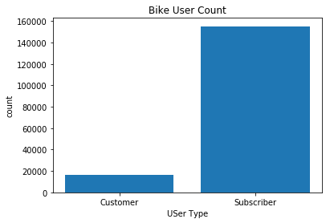

```python
#Create bar chart of the user count
x = ford_bike_1['user_type'].unique()
y = ford_bike_1['user_type'].value_counts(sort=False)
plt.bar(x, y);
plt.title('Bike User Count')
plt.xlabel('USer Type')
plt.ylabel('count')
plt.show()
```

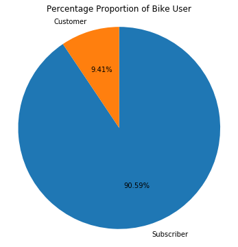

```python
#Create a pie chart showing a proportions of user count
plt.figure(figsize=(8,6))
count = ford_bike_1['user_type'].value_counts()
plt.pie(count, labels = count.index, startangle = 90, counterclock = False, autopct='%1.2f%%')
plt.axis('square');
plt.title('Percentage Proportion of Bike User');
```

From the pie chart we can deduce that the user type consists of 90.5% of subscribers, which is the major client base and customer accounts for 9.5% which happens to be casual patronage.

### What is the Member Gender Proportion ?

```python
# Member_gender counts
ford_bike_1['member_gender'].value_counts(sort=False)
```

```
Female     40805
Male      130500
Name: member_gender, dtype: int64
```

```python
ford_bike_1['member_gender'].unique()
```

```
array(['Male', 'Female'], dtype=object)
```

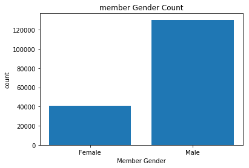

```python
# Create a Bar chart showing the representation of the member gender
x = ford_bike_1['member_gender'].unique()
y = ford_bike_1['member_gender'].value_counts()
plt.bar(x, y);
plt.title('member Gender Count')
plt.xlabel('Member Gender')
plt.ylabel('count')
plt.show()
```

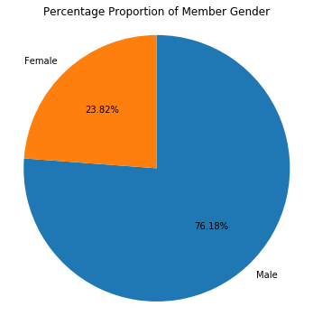

```python
# Create a pie chart showing the proportions of member Gender
plt.figure(figsize=(8,6))
count = ford_bike_1['member_gender'].value_counts()
plt.pie(count, labels = count.index, startangle = 90, counterclock = False, autopct='%1.2f%%')
plt.axis('square');
plt.title('Percentage Proportion of Member Gender');
```

#### Observing the distribution of the main variable of interest: Age.

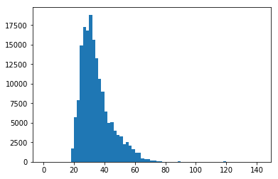

```python
# start with a standard-scaled plot
bins = np.arange(0, ford_bike_1['Age'].max()+2, 2)
plt.hist(data=ford_bike_1, x='Age', bins=bins);
```

From the above chart, It is not suprising that the Ford GoBike sharing system data base consists of peak patronage at ages between 25 and 35 class and the patronage reduces as the age increases from left to right across the Chart.

#### Observing the distribution of another variable of interest: Duration in seconds.

```python
# descriptive statistics for duration_sec
ford_bike_1['duration_sec'].describe()
```

```
count    171305.000000
mean        697.757981
std        1577.253741
min          61.000000
25%         322.000000
50%         509.000000
75%         787.000000
max       84548.000000
Name: duration_sec, dtype: float64
```

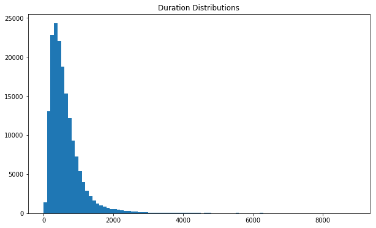

```python
#Create Histogram chart to show the time duration in seconds
plt.figure(figsize=(10,6))
bins = np.arange(0, 9000, 100)

plt.hist(data=ford_bike_1, x='duration_sec', bins=bins)
plt.title('Duration Distributions');
```

There's a long tail in the distribution, so let's put it on a log scale instead

```python
# Descriptive Statistics of log duration_sec
np.log10(ford_bike_1['duration_sec'].describe())
```

```
count    5.233770
mean     2.843705
std      3.197902
min      1.785330
25%      2.507856
50%      2.706718
75%      2.895975
max      4.927103
Name: duration_sec, dtype: float64
```

[figure not shown]

```python
# log scale of duration in secs.

bins = 10 ** np.arange(1, 5+0.1, 0.1)
ticks = [10, 30, 100, 300, 1000, 3000, 10000, 30000, 100000]
labels = ['{}'.format(v) for v in ticks]
plt.hist(data=ford_bike_1, x='duration_sec', bins=bins);
plt.xscale('log')
plt.xticks(ticks, labels)
plt.yticks([5000, 10000, 15000, 20000, 25000], ['5k', '10k', '15k', '2k', '25k'])
plt.title('Duration Distributions')
plt.xlabel('Duration in seconds')
plt.ylabel('Duration Counts');
```

### Discuss the distribution(s) of your variable(s) of interest. Were there any unusual points? Did you need to perform any transformations?

> The duration_sec variable took on a large range of values, so I looked at the data using a log transform. Under the transformation, the data looked unimodal, with a peak between 500 and 800.

### Of the features you investigated, were there any unusual distributions? Did you perform any operations on the data to tidy, adjust, or change the form of the data? If so, why did you do this?

> During investigation I had to transform a column in the dataset from member_birth_year to Age to aid the investigation. While accessing the dataset I noticed about 3652 Other gender present in member_gender column which was dropped to focus the investigation for male and female users.

## Bivariate Exploration

> In this section, investigation relationships between pairs of variables in the datasets were carried out some of which was introduced under univariate Exploration.

#### What's the Relationship between Age and Duration in seconds

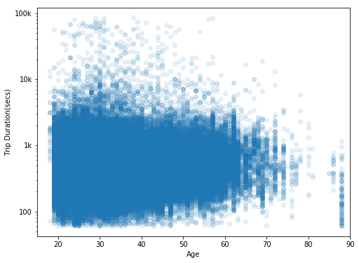

```python
# Bivariate plot of Age vs. Duration in seconds
def bivarate_1():
  # plotting
  plt.figure(figsize = [8,6])
  plt.scatter(data = ford_bike_1, x = 'Age', y = 'duration_sec', alpha = 1/10)
  plt.xlim([15, 90])
  plt.xlabel('Age')
  plt.yscale('log')
  plt.yticks([100, 1000, 10000, 100000], [100, '1k', '10k', '100k'])
  plt.ylabel('Trip Duration(secs)')
  plt.show()
bivarate_1()
```

The Scatter chart of Age against Duration shows a non-linear relationship between both variables. though it is not surprising that as the Age increases from left to right the duration in seconds tends to reduce across the chart.

#### How long does the average trip take?

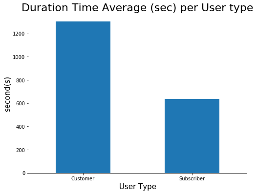

```python
# Plotting trip duration comparison

user_duration = ford_bike_1[['user_type', 'duration_sec']].groupby('user_type').mean()
ax = user_duration.plot(kind='bar', figsize=(8,6));

ax.set_title("Duration Time Average (sec) per User type", fontsize=22)
ax.set_ylabel("second(s)", fontsize=15)
ax.set_xlabel("User Type", fontsize=15)
plt.xticks(rotation=0)

# Remove unnecessary features
ax.get_legend().remove()
ax.spines['top'].set_visible(False)
ax.spines['right'].set_visible(False)
ax.spines['left'].set_visible(False)

plt.show();
```

```python
user_duration
```

| user_type | duration_sec |
| --- | --- |
| Customer | 1302.512658 |
| Subscriber | 634.955680 |

The Bar Chart shows the relationship between the user type and average duration in seconds with Customer type having over 1300 average seconds duration in all trips and Subscriber have over 600 average duration in second. This implies that their casual users travel twice more than their clients in average duration of trips in seconds.

#### What is the Relationship between User Type and Member Gender ?

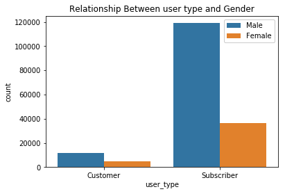

```python
#Observing the realtionship between user_type and member_gender using a clustered plot
ax = sb.countplot(data = ford_bike_1, x = 'user_type', hue = 'member_gender')
ax.legend(loc = 1, framealpha = 1)
plt.title('Relationship Between user type and Gender');
```

#### Now let's take a look at the relationship between Age and the two categorical quality features, member_gender and user_type.

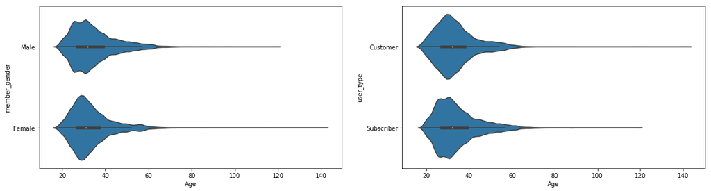

```python
# Bivariate plots of Age vs. member_gender and user_type using violinplot

plt.figure(figsize= [20,5])
base_color = sb.color_palette()[0]
plt.subplot(1,2,1)
sb.violinplot(data=ford_bike_1, x='Age', y='member_gender', color=base_color);
plt.subplot(1,2,2)
sb.violinplot(data=ford_bike_1, x='Age', y='user_type', color=base_color);
```

From the above charts, we can deduct that the male gender have peak patronage for the ages 30-35 while the female gender have peak patronage for ages 30 and involves more aged people compared with the male counterpart. While for the Age vs user type chart, we have the subscribers at ages 27-33 and customer around age 30.

#### What's the relationship between duration sec with User Type and Gender ?

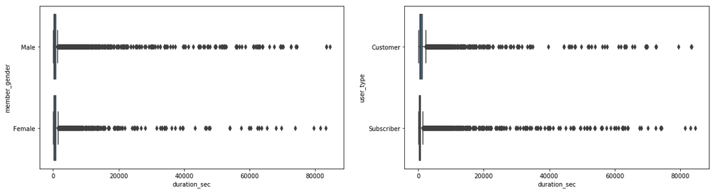

```python
# Create a Boxplot of duration in secs against user_type and member_gender
plt.figure(figsize= [20,5])
base_color = sb.color_palette()[0]
plt.subplot(1,2,1)
sb.boxplot(data=ford_bike_1, x='duration_sec', y='member_gender', color=base_color);
plt.subplot(1,2,2)
sb.boxplot(data=ford_bike_1, x='duration_sec', y='user_type', color=base_color);
```

### Talk about some of the relationships you observed in this part of the investigation. How did the feature(s) of interest vary with other features in the dataset?

> Most of the users of Ford Gobike is between the Ages of 25 to 35. This is not suprising as younger people tend to exercise more.

## Multivariate Exploration

> Create plots of three or more variables to investigate your data even further. Make sure that your investigations are justified, and follow from your work in the previous sections.

#### What's the relationship between Age, Gender and User Type

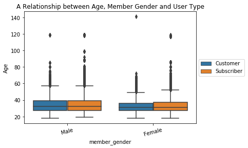

```python
#Multivariate plot of Age by member_gender and user_type, for approx. 1 carat diamonds
sb.boxplot(data = ford_bike_1, x = 'member_gender', y = 'Age', hue = 'user_type');
plt.legend(loc = 6, bbox_to_anchor = (1.0, 0.5)) # legend to right of figure
plt.xticks(rotation = 15)
plt.title('A Relationship between Age, Member Gender and User Type');
```

#### what's the relationship between Age, User type and Duration in seconds

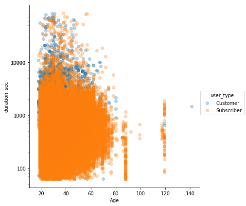

```python
g = sb.FacetGrid(data = ford_bike_1, hue = 'user_type', size = 6);
g.map(plt.scatter, 'Age', 'duration_sec', alpha=0.3)
g.set(yscale = 'log') # need to set scaling before customizing ticks
y_ticks = [100, 1000, 10000, 10000]
g.set(yticks = y_ticks, yticklabels = y_ticks)
g.add_legend();
```